# Forest Fires

PSTAT 126 Project Step 4

Pariya Akhiani, Syed Khaled, Henry McMahon, Sofia Ward

Northeast Region of Portugal 2-28-2008

#### Introduction

This dataset is part of the UCI Machine Learning Repository. The data can be used to predict the burned area of a forest fire given information about weather conditions and fuel moisture.

The data was taken from Montesinho Natural Park in northeastern Portugal in 2007-2008.

#### Variable Content

1. **x-axis :** x-coordinate with respect to the Montesinho Park Map: 1 to 9
2. **y-axis :** y-coordinate with respect to the Montesinho Park Map: 2 to 9
3. **Month :** categorical data type representing the month: ‘jan’ to ‘dec’
4. **Day :** categorical data type representing the day of the week: ‘mon’ to ‘sun’
5. **FFMC :** Fine Fuel Moisture Code index (from the FWI system): 18.7 to 96.20
   - continuous numerical value representing the fine fuel moisture of fuels 1-2cm deep from the ground (surface layer)
   - It expresses the ease of ignition and fuel flammability.
   - FFMC is sensitive to daily changes in temperature, rainfall, relative humidity, and wind speed. The time lag is 2/3 day, so it takes approximately 16 hours for changes in weather to affect the fine fuel. Higher fine fuel value is representative of more flammable fuel present in the surface layer.
6. **DMC :** Duff Moisture Code index (from the FWI system): 1.1 to 291.3
   - continuous numerical value representing the fuel moisture of decomposed organic material underneath the fine fuel, 5-10 cm deep. A higher value corresponds to less moisture present.
   - The time lag of weather impacting DMC is 12 days
7. **DC :** Drought Code index (from the FWI system): 7.9 to 860.6
   - continuous numerical value representing the moisture of compacted organic material 10-20 cm deep
   - indicates seasonal drought effects and smoldering in deep layers
   - The time lag of weather impacting DC is 52 days
   - Higher DC signifies drought conditions
8. **ISI :** Inital Spread Index (from the FWI system): 0.0 to 56.10
   - continuous numeric rating of initial fire spread, which does not depend on fuel, but rather wind speed and time of day. Higher ISI is associated with fire risk.
9. **Temp :** temperature in Celsius: 2.2 to 33.30
10. **RH :** relative humidity (percentage): 15.0 to 100
11. **Wind :** wind speed in km/h: 0.40 to 9.40
12. **Area :** the burned area of the forest (in ha): 0.00 to 1090.84
    - this output variable is very skewed towards 0.0, thus it may make sense to model with the logarithm transform.

```
##
## Call:
## lm(formula = log_ISI ~ . - ISI, data = forestfires)
##
## Residuals:
##      Min       1Q   Median       3Q      Max
## -0.59034 -0.15750 -0.01558  0.12401  1.33475
##
## Coefficients:
##                 Estimate Std. Error t value Pr(>|t|)
## (Intercept)   15.8746970  1.3575199  11.694  < 2e-16 ***
## X              0.0039232  0.0053576   0.732 0.464349
## Y              0.0012524  0.0101073   0.124 0.901437
## daymon        -0.1292420  0.0379292  -3.407 0.000709 ***
## daysat        -0.0655472  0.0367555  -1.783 0.075144 .
## daysun        -0.0622563  0.0355104  -1.753 0.080188 .
## daythu        -0.1276637  0.0404216  -3.158 0.001684 **
## daytue        -0.0501831  0.0394707  -1.271 0.204182
## daywed        -0.0147083  0.0416444  -0.353 0.724097
## FFMC           0.1625246  0.0076317  21.296  < 2e-16 ***
## DMC           -0.0002561  0.0002863  -0.894 0.371577
## DC            -0.0001881  0.0001256  -1.497 0.134925
## temp           0.0012653  0.0035092   0.361 0.718565
## RH             0.0014361  0.0009754   1.472 0.141562
## wind           0.0340327  0.0062040   5.486 6.58e-08 ***
## rain          -0.0271522  0.0362591  -0.749 0.454309
## area          -0.0000728  0.0001648  -0.442 0.658943
## log_FFMC      -6.3794174  0.4411153 -14.462  < 2e-16 ***
## seasonsSpring  0.0972237  0.0558202   1.742 0.082176 .
## seasonsSummer  0.3623445  0.0770064   4.705 3.29e-06 ***
## seasonsFall    0.2827856  0.0846916   3.339 0.000904 ***
## ---
## Signif. codes:  0 '***' 0.001 '**' 0.01 '*' 0.05 '.' 0.1 ' ' 1
##
## Residual standard error: 0.2338 on 496 degrees of freedom
## Multiple R-squared:  0.767,  Adjusted R-squared:  0.7576
## F-statistic: 81.62 on 20 and 496 DF,  p-value: < 2.2e-16
```

|  | X | Y | FFMC | DMC | DC | ISI | temp | RH | wind | rain | area |
| --- | --- | --- | --- | --- | --- | --- | --- | --- | --- | --- | --- |
| X | **1** | **0.54** | -0.02 | -0.05 | -0.09 | 0.01 | -0.05 | 0.09 | 0.02 | 0.07 | 0.06 |
| Y | **0.54** | **1** | -0.05 | 0.01 | -0.1 | -0.02 | -0.02 | 0.06 | -0.02 | 0.03 | 0.04 |
| FFMC | -0.02 | -0.05 | **1** | 0.38 | 0.33 | **0.53** | 0.43 | -0.3 | -0.03 | 0.06 | 0.04 |
| DMC | -0.05 | 0.01 | 0.38 | **1** | **0.68** | 0.31 | 0.47 | 0.07 | -0.11 | 0.07 | 0.07 |
| DC | -0.09 | -0.1 | 0.33 | **0.68** | **1** | 0.23 | 0.5 | -0.04 | -0.2 | 0.04 | 0.05 |
| ISI | 0.01 | -0.02 | **0.53** | 0.31 | 0.23 | **1** | 0.39 | -0.13 | 0.11 | 0.07 | 0.01 |
| temp | -0.05 | -0.02 | 0.43 | 0.47 | 0.5 | 0.39 | **1** | **-0.53** | -0.23 | 0.07 | 0.1 |
| RH | 0.09 | 0.06 | -0.3 | 0.07 | -0.04 | -0.13 | **-0.53** | **1** | 0.07 | 0.1 | -0.08 |
| wind | 0.02 | -0.02 | -0.03 | -0.11 | -0.2 | 0.11 | -0.23 | 0.07 | **1** | 0.06 | 0.01 |
| rain | 0.07 | 0.03 | 0.06 | 0.07 | 0.04 | 0.07 | 0.07 | 0.1 | 0.06 | **1** | -0.01 |
| area | 0.06 | 0.04 | 0.04 | 0.07 | 0.05 | 0.01 | 0.1 | -0.08 | 0.01 | -0.01 | **1** |

```
##             X             Y        daymon        daysat        daysun
##      1.450547      1.458638      1.668720      1.738646      1.788743
##        daythu        daytue        daywed          FFMC           DMC
##      1.608135      1.598193      1.534222     16.752602      3.174682
##            DC          temp            RH          wind          rain
##      9.163115      3.919187      2.390973      1.166239      1.087020
##          area      log_FFMC seasonsSpring seasonsSummer   seasonsFall
##      1.039317     14.837746      3.239180     13.884421     15.697670
```

## Ridge Regression

```
## Best lambda: 0.03641947
```

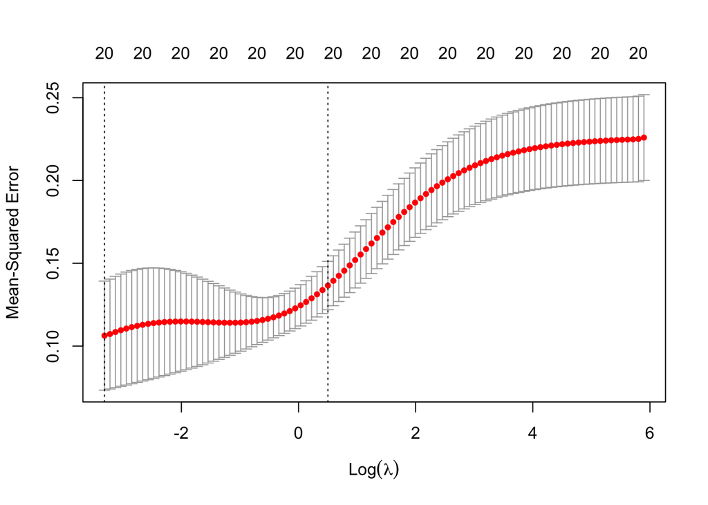

```
## Coefficients of the best model:
```

```
## 21 x 1 sparse Matrix of class "dgCMatrix"
##                          s0
## (Intercept)    2.2040231605
## X              0.0076032591
## Y             -0.0003778357
## daymon        -0.0450400843
## daysat        -0.0229651546
## daysun        -0.0169172086
## daythu        -0.0324555784
## daytue        -0.0129819554
## daywed         0.0076030927
## FFMC           0.3623221989
## DMC            0.0084906769
## DC             0.0181191846
## temp           0.0526492809
## RH             0.0213981336
## wind           0.0491162598
## rain          -0.0023773828
## area          -0.0045065235
## log_FFMC      -0.0759412358
## seasonsSpring  0.0251683932
## seasonsSummer  0.0964577710
## seasonsFall    0.0390087304
```

## Lasso Regression

```
## Best lambda: 0.004187353
```

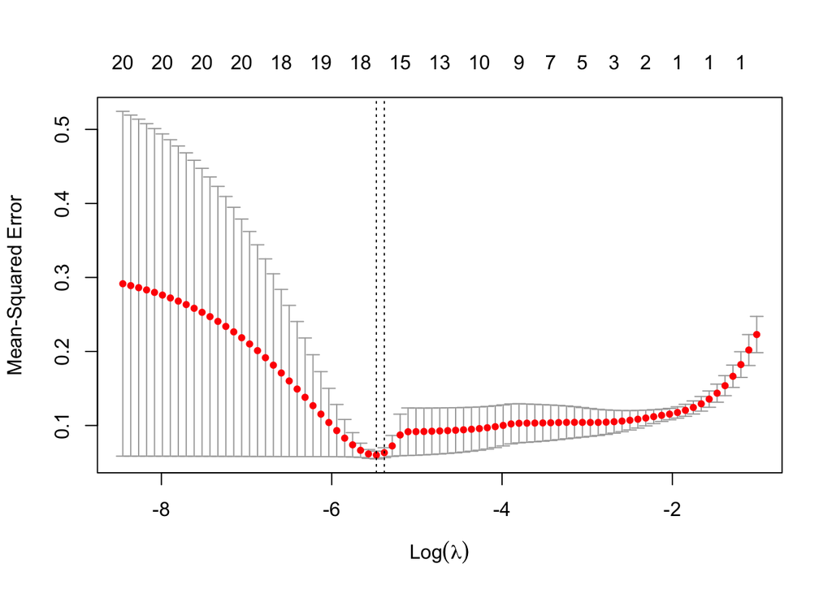

```
## Coefficients of the best model:
```

```
## 21 x 1 sparse Matrix of class "dgCMatrix"
##                          s0
## (Intercept)    2.2040231605
## X              0.0063475099
## Y              .
## daymon        -0.0317717254
## daysat        -0.0087258253
## daysun        -0.0051563929
## daythu        -0.0271224354
## daytue        -0.0009642298
## daywed         0.0046188251
## FFMC           0.7761470624
## DMC           -0.0038802755
## DC             .
## temp           0.0150830560
## RH             0.0174001442
## wind           0.0528105807
## rain          -0.0028439662
## area          -0.0013416127
## log_FFMC      -0.4522785438
## seasonsSpring  0.0032578952
## seasonsSummer  0.0821077486
## seasonsFall    0.0298235081
```

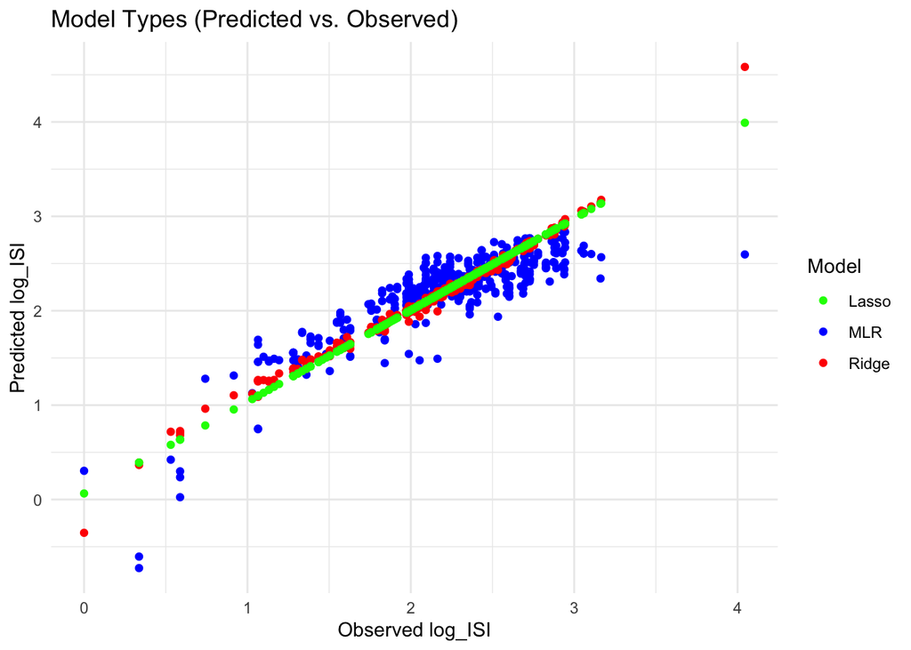

Overall, the models performed well, with Ridge and Lasso offering valuable insights into the data’s underlying structure, while MLR provided a useful baseline. Further exploration into variable interactions and model tuning is recommended to refine predictions and enhance model accuracy.

## FACTOR ANALYSIS

Factor analysis can be highly beneficial for a dataset particularly when it comes to dimensional reduction, and understanding underlying relationships. Reducing the number of dimensions to two or three factors can allow for meaningful visualizations, making it easier to identify patterns, clusters, and outliers in the data.

```
## Principal Components Analysis
## Call: principal(r = factor_data, nfactors = 2, rotate = "varimax")
## Standardized loadings (pattern matrix) based upon correlation matrix
##        RC1  RC2   h2   u2 com
## temp -0.87 0.09 0.77 0.23 1.0
## RH    0.81 0.04 0.66 0.34 1.0
## wind  0.37 0.47 0.36 0.64 1.9
## area -0.26 0.38 0.21 0.79 1.7
## rain  0.01 0.82 0.67 0.33 1.0
##
##                        RC1  RC2
## SS loadings           1.62 1.04
## Proportion Var        0.32 0.21
## Cumulative Var        0.32 0.53
## Proportion Explained  0.61 0.39
## Cumulative Proportion 0.61 1.00
##
## Mean item complexity =  1.3
## Test of the hypothesis that 2 components are sufficient.
##
## The root mean square of the residuals (RMSR) is  0.19
##  with the empirical chi square  364.49  with prob <  3e-81
##
## Fit based upon off diagonal values = 0.04
```

```
## Principal Components Analysis
## Call: principal(r = minimized_factor_data, nfactors = 2, rotate = "varimax")
## Standardized loadings (pattern matrix) based upon correlation matrix
##        RC1   RC2   h2    u2 com
## temp  0.80 -0.30 0.73 0.268 1.3
## wind -0.06  0.97 0.95 0.048 1.0
## FFMC  0.88  0.12 0.79 0.208 1.0
##
##                        RC1  RC2
## SS loadings           1.42 1.06
## Proportion Var        0.47 0.35
## Cumulative Var        0.47 0.83
## Proportion Explained  0.57 0.43
## Cumulative Proportion 0.57 1.00
##
## Mean item complexity =  1.1
## Test of the hypothesis that 2 components are sufficient.
##
## The root mean square of the residuals (RMSR) is  0.16
##  with the empirical chi square  81.2  with prob <  NA
##
## Fit based upon off diagonal values = 0.67
```

In the context of fire weather modeling or analysis, variables like ‘wind’ and ‘FFMC’ are crucial factors that influence fire behavior and fire danger assessments.